# Predicting season win totals NCAA football 2024

Me

2024-10-09 10:32:40.985905

```r
library(tidyverse)
library(tidymodels)
```

Let’s play with NCAA football data from this year… some tough stuff happened this past weekend… Let’s dig for hope in the data.

We’ll have the goal of some hands-on data manipulation+regression practice and exposure to the `tidymodels` way of doing things.

## Data overview

The data was scraped on 2024-10-08 from sports-reference.com. The scraped data can be found here:

- [Raw data](https://docs.google.com/spreadsheets/d/1wB3jSXi_icELvBw8fXM6GNdyP9ElzJkp_Zw7kFn1C1E/edit?usp=sharing)
- [Reshaped data for our activity](https://docs.google.com/spreadsheets/d/198RbUWYiA5mYklpvAE1TEqMk3ud7uh74_YKIv8Uhno0/edit?usp=sharing)

Each of those can be read into R with the below code:

```r
# Data for each game result from 2015 through 2024 week 7
# Columns: c("date", "datetime", "day_of_week", "week", "winner",
#            "winner_pts", "winner_rank", "loser", "loser_pts",
#            "loser_rank", "home_team", "notes")
raw_data_url <- "https://docs.google.com/spreadsheets/d/1wB3jSXi_icELvBw8fXM6GNdyP9ElzJkp_Zw7kFn1C1E/export?format=csv"

ncaaf_df <- read.csv(raw_data_url) |>
  mutate(time = as_datetime(paste(date, time), format = "%Y-%m-%d %I:%M %p")) |>
  rename(datetime = time)

head(ncaaf_df)
```

|  | date | datetime | day_of_week | week | winner | winner_pts | winner_rank | loser | loser_pts | loser_rank | home_team | notes |
| --- | --- | --- | --- | --- | --- | --- | --- | --- | --- | --- | --- | --- |
| 1 | 2015-09-03 | 2015-09-03 22:00:00 | Thu | 1 | Arizona | 42 | 22 | Texas-San Antonio | 32 | NA | Arizona |  |
| 2 | 2015-09-03 | 2015-09-03 19:00:00 | Thu | 1 | Ball State | 48 | NA | Virginia Military Institute | 36 | NA | Ball State |  |
| 3 | 2015-09-03 | 2015-09-03 19:30:00 | Thu | 1 | Connecticut | 20 | NA | Villanova | 15 | NA | Connecticut |  |
| 4 | 2015-09-03 | 2015-09-03 21:30:00 | Thu | 1 | Duke | 37 | NA | Tulane | 7 | NA | Tulane |  |
| 5 | 2015-09-03 | 2015-09-03 18:00:00 | Thu | 1 | Florida International | 15 | NA | Central Florida | 14 | NA | Central Florida |  |
| 6 | 2015-09-03 |  | Thu | 1 | Fresno State | 34 | NA | Abilene Christian | 13 | NA | Fresno State |  |

```r
# Data for wins, losses, points for, and points against;
# totals for season and for week 1 through 7
# Columns: c("year", "team", "win_count", "loss_count", "points_scored",
#            "points_allowed", "win_count_w7", "loss_count_w7",
#            "points_scored_w7", "points_allowed_w7")
w7_data_url <- "https://docs.google.com/spreadsheets/d/198RbUWYiA5mYklpvAE1TEqMk3ud7uh74_YKIv8Uhno0/export?format=csv"

w7_df <- read.csv(w7_data_url)

head(w7_df)
```

|  | year | team | win_count | loss_count | points_scored | points_allowed | win_count_w7 | loss_count_w7 | points_scored_w7 | points_allowed_w7 |
| --- | --- | --- | --- | --- | --- | --- | --- | --- | --- | --- |
| 1 | 2015 | Clemson | 14 | 0 | 537 | 280 | 6 | 0 | 211 | 100 |
| 2 | 2015 | Alabama | 13 | 1 | 481 | 187 | 6 | 1 | 249 | 117 |
| 3 | 2015 | Houston | 13 | 1 | 566 | 290 | 6 | 0 | 274 | 128 |
| 4 | 2015 | Iowa | 12 | 1 | 417 | 240 | 7 | 0 | 230 | 107 |
| 5 | 2015 | Michigan State | 12 | 2 | 417 | 304 | 7 | 0 | 215 | 151 |
| 6 | 2015 | Western Kentucky | 12 | 2 | 620 | 363 | 6 | 1 | 308 | 168 |

## EDA

Let’s use the data totaled through week 7 `w7_df`. Start by just viewing what’s going on in here.

```r
head(w7_df)
```

|  | year | team | win_count | loss_count | points_scored | points_allowed | win_count_w7 | loss_count_w7 | points_scored_w7 | points_allowed_w7 |
| --- | --- | --- | --- | --- | --- | --- | --- | --- | --- | --- |
| 1 | 2015 | Clemson | 14 | 0 | 537 | 280 | 6 | 0 | 211 | 100 |
| 2 | 2015 | Alabama | 13 | 1 | 481 | 187 | 6 | 1 | 249 | 117 |
| 3 | 2015 | Houston | 13 | 1 | 566 | 290 | 6 | 0 | 274 | 128 |
| 4 | 2015 | Iowa | 12 | 1 | 417 | 240 | 7 | 0 | 230 | 107 |
| 5 | 2015 | Michigan State | 12 | 2 | 417 | 304 | 7 | 0 | 215 | 151 |
| 6 | 2015 | Western Kentucky | 12 | 2 | 620 | 363 | 6 | 1 | 308 | 168 |

## Pythagorean win-loss data manipulation

Let’s calculate [Pythagorean win-loss](https://en.wikipedia.org/wiki/Pythagorean_expectation) through week 7 (aka Pythagorean expectation, aka Pythagorean wins, aka Pythagorean projection).

*Note: No, Pythagorean win loss will not be on any quiz/test/lab.*

Pythagorean win-loss percentage in theory is a way to to show how many games a team “should have won” and “should win” if they continue with their current scoring performance. It compares points scored to points allowed and is trying to reflect things like: “that team isn’t as good as their record, they just keep eking by with close lucky wins” and “that team’s great, they’re blowing out everyone”. You can debate if you agree with what this is trying to measure and if it captures it.

$$\frac{\text{points_scored}^2}{\text{points_scored}^2 +
\text{points_allowed}^2}$$

(according to [an implementation for the NFL](https://en.wikipedia.org/wiki/Pythagorean_expectation#Use_in_the_National_Football_League) maybe $2.37$ is a better exponent for projections than $2$)

Calculate both regular win/loss percentage and Pythagorean win/loss using just statistics through week 7.

```r
w7_df <- w7_df |>
  mutate(pythag_winloss_w7 = points_scored_w7^2 / (points_scored_w7^2 + points_allowed_w7^2)) |>
  mutate(winloss_w7 = win_count_w7 / (win_count_w7 + loss_count_w7)) |>
  mutate(pythag_winloss = points_scored^2 / (points_scored^2 + points_allowed^2)) |>
  mutate(winloss = win_count / (win_count + loss_count))
```

One of the claims with this Pythagorean win loss is that we can identify “under-performing” and “over-performing” teams (again, you can debate the rationale).

Let’s follow this idea. To start we need to calculate the difference between Pythagorean win loss and actual win loss.

```r
w7_df <- w7_df |>
  mutate(winloss_diff_w7 = pythag_winloss_w7 - winloss_w7) |>
  mutate(winloss_diff = pythag_winloss - winloss)
```

Who are the biggest over and under performers for 2024?

Interpretation guide:

- More negative `winloss_diff_w7` -> bigger fraud
- More positive `winloss_diff_w7` -> more unlucky breaks

```r
only_2024 <- w7_df |>
  filter(year == 2024) |>
  select(
    team, win_count_w7, points_scored_w7, points_allowed_w7,
    pythag_winloss_w7, winloss_w7, winloss_diff_w7
  )

# Unluckiest teams
only_2024  |>
  arrange(desc(winloss_diff_w7)) |>
  head()
```

|  | team | win_count_w7 | points_scored_w7 | points_allowed_w7 | pythag_winloss_w7 | winloss_w7 | winloss_diff_w7 |
| --- | --- | --- | --- | --- | --- | --- | --- |
| 1 | Kansas | 1 | 171 | 154 | 0.5521650 | 0.1666667 | 0.3854983 |
| 2 | Auburn | 2 | 180 | 125 | 0.6746486 | 0.3333333 | 0.3413153 |
| 3 | South Alabama | 2 | 219 | 163 | 0.6435127 | 0.3333333 | 0.3101793 |
| 4 | Rice | 1 | 124 | 132 | 0.4687805 | 0.2000000 | 0.2687805 |
| 5 | Baylor | 2 | 168 | 144 | 0.5764706 | 0.3333333 | 0.2431373 |
| 6 | Mississippi State | 1 | 137 | 158 | 0.4291725 | 0.2000000 | 0.2291725 |

```r
# Biggest frauds
only_2024  |>
  arrange(winloss_diff_w7) |>
  head()
```

|  | team | win_count_w7 | points_scored_w7 | points_allowed_w7 | pythag_winloss_w7 | winloss_w7 | winloss_diff_w7 |
| --- | --- | --- | --- | --- | --- | --- | --- |
| 1 | Louisiana-Monroe | 4 | 99 | 99 | 0.5000000 | 0.8000000 | -0.3000000 |
| 2 | Arkansas State | 3 | 105 | 151 | 0.3259327 | 0.6000000 | -0.2740673 |
| 3 | Liberty | 4 | 134 | 82 | 0.7275527 | 1.0000000 | -0.2724473 |
| 4 | Buffalo | 3 | 90 | 121 | 0.3561849 | 0.6000000 | -0.2438151 |
| 5 | Texas Tech | 5 | 236 | 194 | 0.5967514 | 0.8333333 | -0.2365820 |
| 6 | Pittsburgh | 5 | 228 | 126 | 0.7660477 | 1.0000000 | -0.2339523 |

```r
# How bout them vols
# Pythag says we're better than our record
only_2024 |>
  filter(team == "Tennessee")
```

| team | win_count_w7 | points_scored_w7 | points_allowed_w7 | pythag_winloss_w7 | winloss_w7 | winloss_diff_w7 |
| --- | --- | --- | --- | --- | --- | --- |
| Tennessee | 4 | 230 | 47 | 0.9599158 | 0.8 | 0.1599158 |

The other claim with this metric is that it can be used to project end of season wins.

$$\text{Pythagorean wins} =
\frac{\text{points_scored}^{2}}{\text{points_scored}^{2} +
\text{points_allowed}^{2}} \times \text{number_of_games}$$

Let’s make some predictions for the end of season win totals.

```r
n_games = 12

w7_df <- w7_df |>
  mutate(pythag_wins_proj_w7 = pythag_winloss_w7 * n_games)
```

One of the benefits of “supervised learning” is we can measure if we’re on the right track by comparing to the right answer. In this case, for past seasons, if we’d used this projection, how close would we have been? These mistakes are called residuals or errors depending on context and who you’re talking to.

$$\text{residual} = y - \hat{y}$$

Residual is actual ( $y$ ) minus predicted ( $\hat{y}$ ). “Wizard’s make predictions and they wear pointy hats” - Jessica circa Jan 2022

```r
w7_df <- w7_df |>
  mutate(pythag_residual = win_count - pythag_wins_proj_w7)

summary(w7_df$pythag_residual)
```

```
##     Min.  1st Qu.   Median     Mean  3rd Qu.     Max.     NA's
## -6.50704 -1.44089 -0.17737 -0.05369  1.23028  6.37900      196
```

How can we we find the typical mistake?

```r
mean(abs(w7_df$pythag_residual), na.rm = TRUE)
```

```
## [1] 1.593198
```

```r
sqrt(mean((w7_df$pythag_residual)^2, na.rm = TRUE))
```

```
## [1] 1.989738
```

Okay, how bout them Vols. This prediction we’ll assume is under predicted…

```r
w7_df |>
  filter(team == "Tennessee") |>
  filter(year == 2024) |>
  select(team, year, pythag_winloss_w7, pythag_wins_proj_w7)
```

| team | year | pythag_winloss_w7 | pythag_wins_proj_w7 |
| --- | --- | --- | --- |
| Tennessee | 2024 | 0.9599158 | 11.51899 |

According to [this one implementation for the NFL](https://en.wikipedia.org/wiki/Pythagorean_expectation#Use_in_the_National_Football_League) maybe $2.37$ is a better exponent for projections than $2$…

$$\text{Pythagorean wins} =
\frac{\text{points_scored}^{2.37}}{\text{points_scored}^{2.37} +
\text{points_allowed}^{2.37}} \times \text{number_of_games}$$

for the curious, think through how this exponent is affecting the outcome. Prove it out by plugging in different values for $\text{points_scored}$, $\text{points_allowed}$, and the exponent value.

but what value is actually the best for NCAA football…? We want to choose some $t$ that seems to perform the best… but **how can we find the best value for** $t$**?** ( $t$ for $t$ennessee and nothing more meaningful)

$$\text{Pythagorean wins} =
\frac{\text{points_scored}^{t}}{\text{points_scored}^{t} +
\text{points_allowed}^{t}} \times \text{number_of_games}$$

$t$ is an example of a parameter that we want to “tune” to find the best value of. Kind of like coefficients in linear regression.

**So, how might we find the best value of** $t$?

*class discussion about finding best t*

(p.s. if anyone looks into the best value of $t$ for 2015-2023 I’d be curious to know your answer)

**Poke a hole in the logic so far? What is this “model” missing?**

*class discussion about how this model is limited*

**What’s good about this model so far though?**

*class discussion about how this model is good*

## Predicting wins with linear regression

Okie doke, instead of that Pythagorean stuff let’s practice applying linear regression but we’ll use the `tidymodels` framework. Can we predict end of season wins for everyone this year?

Selecting down to some certain columns for modeling. Keeping `year` and `team` as ID variables so we can see who’s who, keeping `win_count` as our *target* (y), keeping some of our week 7 statistics as *predictors* (X).

```r
model_data <- w7_df |>
  select(
    year, team, win_count,
    win_count_w7, points_scored_w7,
    points_allowed_w7, winloss_w7
  )
```

### Using a `recipe()` for `tidymodels`

We’re going to predict `win_count` using all available *predictors*.

- `recipe()` - is where we outline what will be our *target* (y), our *predictors*/*features* (Xs), and what data.frame the data is coming from
- `update_role()` - I don’t want to use `year` and `team` as predictors, I’d rather think of them as IDs. So I’m letting the recipe know to treat them with the `role` of `ID`.
- `step_naomit()` - dropping all records with an `NA` for any of the numeric predictors
- `step_corr()` - dropping correlated predictors
- `step_lincomb()` - dropping predictors that are linear combinations of one another
- `step_nzv()` - dropping variables with near zero variance

Running `prep()` let’s us see some status print outs about what our recipe’s results are.

```r
ncaa_recipe <- recipe(win_count ~ ., data = model_data) |>
  update_role(year, new_role = "ID") |>
  update_role(team, new_role = "ID") |>
  step_naomit(all_numeric_predictors()) |>
  step_corr(all_numeric_predictors()) |>
  step_lincomb(all_numeric_predictors()) |>
  step_nzv(all_numeric_predictors())

ncaa_recipe |>
  prep()
```

```
## ── Recipe ──────────────────────────────────────────────────────────────────────
```

```
## ── Inputs
```

```
## Number of variables by role
```

```
## outcome:   1
## predictor: 4
## ID:        2
```

```
## ── Training information
```

```
## Training data contained 1295 data points and 196 incomplete rows.
```

```
## ── Operations
```

```
## • Removing rows with NA values in: win_count_w7, ... | Trained
```

```
## • Correlation filter on: winloss_w7 | Trained
```

```
## • Linear combination filter removed: <none> | Trained
```

```
## • Sparse, unbalanced variable filter removed: <none> | Trained
```

We can use `bake()` to actually apply the cleaning steps from the `recipe()`. Doing this let’s us view the data the same way as our predictive models will see it.

```r
ncaa_prepped <- ncaa_recipe |>
  prep() |>
  bake(model_data)

ncaa_prepped
```

| year | team | win_count_w7 | points_scored_w7 | points_allowed_w7 | win_count |
| --- | --- | --- | --- | --- | --- |
| 2015 | Clemson | 6 | 211 | 100 | 14 |
| 2015 | Alabama | 6 | 249 | 117 | 13 |
| 2015 | Houston | 6 | 274 | 128 | 13 |
| 2015 | Iowa | 7 | 230 | 107 | 12 |
| 2015 | Michigan State | 7 | 215 | 151 | 12 |
| 2015 | Western Kentucky | 6 | 308 | 168 | 12 |
| 2015 | Appalachian State | 5 | 235 | 71 | 11 |
| 2015 | Navy | 4 | 178 | 101 | 11 |
| 2015 | North Carolina | 5 | 243 | 104 | 11 |
| 2015 | Ohio State | 7 | 259 | 114 | 11 |

[output cut: 1285 more lines]

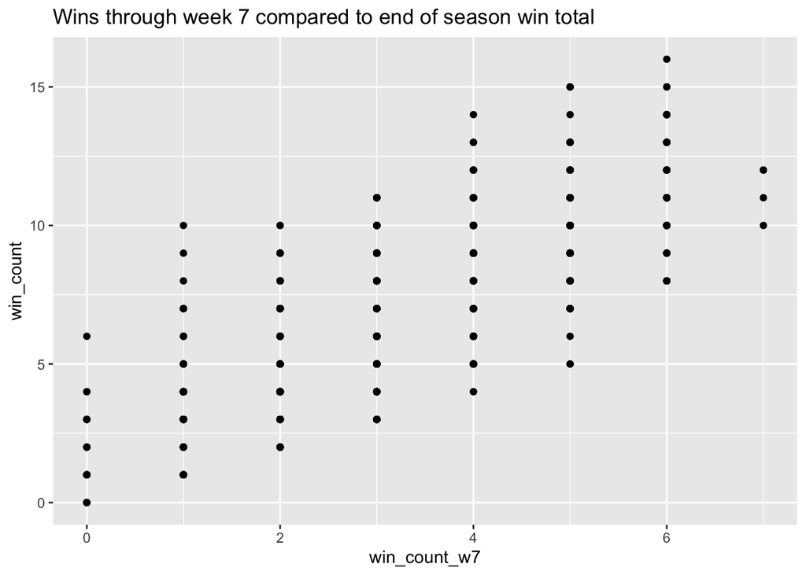

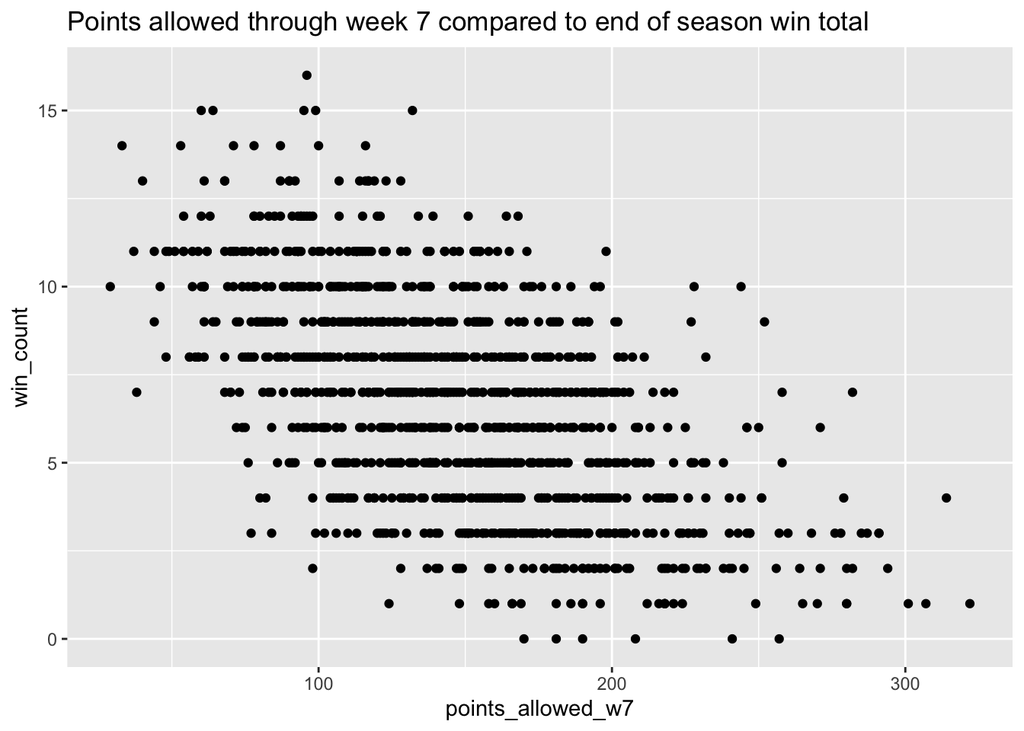

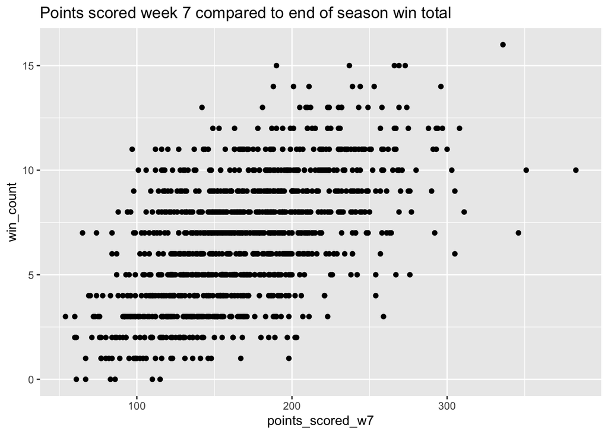

### Using a `workflow()` for `tidymodels`

Fitting a model is little wordier with our newer framework than just saying `lm()`, but it will payoff as a framework to fit more and more complex models.

```r
ncaa_lm <- linear_reg()

ncaa_workflow <- workflow() |>
  add_recipe(ncaa_recipe) |>
  add_model(ncaa_lm)

ncaa_fit <- ncaa_workflow |>
  fit(model_data)
```

Making predictions with our model and adding the predictions as a column to our data.

```r
data_w_preds <- ncaa_fit |>
  predict(model_data) |>
  bind_cols(model_data) |>
  mutate(residual = win_count - .pred)
```

We can look into our biggest misses and the distribution of our misses.

```r
# In 2022 Fresno State had 1 win through week 7 and finished with 10 wins.
# Our model predicted they'd only have 3.86 wins, our residual is 6.14 = 10 - 3.86.
data_w_preds |>
  arrange(desc(residual)) |>
  head(5)
```

| .pred | year | team | win_count | win_count_w7 | points_scored_w7 | points_allowed_w7 | winloss_w7 | residual |
| --- | --- | --- | --- | --- | --- | --- | --- | --- |
| 3.863860 | 2022 | Fresno State | 10 | 1 | 118 | 146 | 0.2000000 | 6.136140 |
| 8.340923 | 2019 | Appalachian State | 14 | 4 | 188 | 116 | 1.0000000 | 5.659077 |
| 7.884959 | 2021 | Louisiana | 13 | 4 | 142 | 114 | 0.8000000 | 5.115041 |
| 9.988571 | 2021 | Alabama | 15 | 5 | 266 | 132 | 0.8333333 | 5.011429 |
| 4.003498 | 2021 | Western Kentucky | 9 | 1 | 202 | 192 | 0.2000000 | 4.996502 |

```r
# In 2018 Colorado had 5 wins through week 7 and finished with 5 wins.
# Our model predicted they'd have 9.83 wins, our residual is -4.83 = 5 - 9.82.
data_w_preds |>
  arrange(residual) |>
  head(5)
```

| .pred | year | team | win_count | win_count_w7 | points_scored_w7 | points_allowed_w7 | winloss_w7 | residual |
| --- | --- | --- | --- | --- | --- | --- | --- | --- |
| 9.825113 | 2018 | Colorado | 5 | 5 | 189 | 92 | 1.0000000 | -4.825113 |
| 7.625592 | 2019 | Maryland | 3 | 3 | 207 | 106 | 0.6000000 | -4.625592 |
| 7.484651 | 2021 | Nebraska | 3 | 3 | 223 | 125 | 0.4285714 | -4.484651 |
| 7.398989 | 2015 | Boston College | 3 | 3 | 141 | 77 | 0.4285714 | -4.398989 |
| 7.812383 | 2019 | Arizona | 4 | 4 | 186 | 147 | 0.8000000 | -3.812383 |

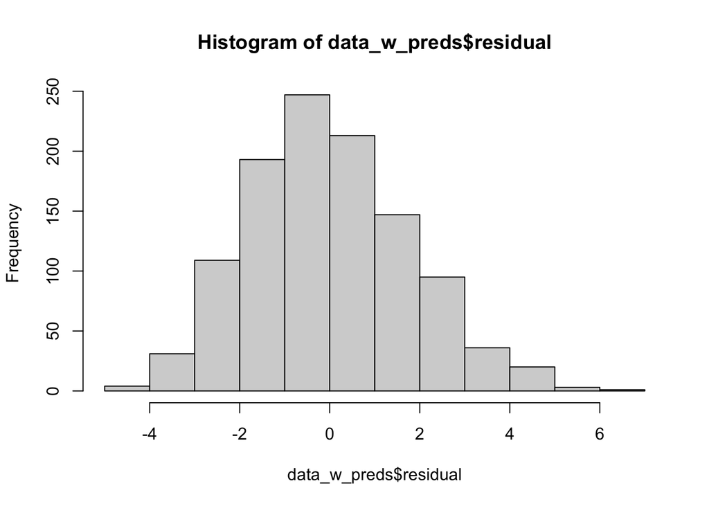

```r
# Our residuals are normally distrubted and cenetered around zero.
hist(data_w_preds$residual)
```

```r
# We can see a five number summary of our mistakes and get a better feel for a typical miss
# We can see our biggest mistakes of Colorado (-4.83) and Fresno State (6.14)
summary(data_w_preds$residual)
```

```
##    Min. 1st Qu.  Median    Mean 3rd Qu.    Max.    NA's
## -4.8251 -1.2604 -0.1356  0.0000  1.1387  6.1361     196
```

### Using `metrics()` to measure accuracy

Measuring the accuracy of our predictions can be done with `metrics()` it can calculate:

- RMSE - root mean squared error - $\sqrt{\frac{1}{n} \sum{(y_i - \hat{y_i})^2}}$ - “typical miss” - our model is typically withing 1.77 wins of the correct season win total
  - Subtract actual $y_i$ and predicted $\hat{y_i}$, square this residual, find the average squared residual, take square root
- $R^2$ - R squared - “variation explained” - wins, points allowed, and points scored at week 7 explain about 66% of the variation in end of season win total
  - Think of as a percentage; closer to 100% the more variation in your y is explained
  - More notes on $R^2$ in homework
- MAE - mean absolute error - $\frac{1}{n} \sum{|y_i - \hat{y_i}|}$ - “typical miss”
  - Subtract actual $y_i$ and predicted $\hat{y_i}$, calculate absolute value of this residual, take average

```r
data_w_preds |>
  metrics(truth = win_count, estimate = .pred)
```

| .metric | .estimator | .estimate |
| --- | --- | --- |
| rmse | standard | 1.7738777 |
| rsq | standard | 0.6603258 |
| mae | standard | 1.4236906 |

#### MAE vs RMSE

- Very similar and often agree.
- RMSE penalizes a little more than MAE for bigger misses and RMSE rewards more than MAE for small misses (squaring numbers larger than 1 makes them get real big; squaring numbers smaller than one makes the numbers smaller)
- *WARNING CALCULUS…* RMSE and its minimum are differentiable, but MAE and it’s minimum looks like `V`…. because of this, a lot of the machinery to optimize models is based around minimizing squared errors rather than absolute errors.

### Extracting fit model from a `tidymodels` `workflow`

Often you see some online tutorial doing things with the fit model but they didn’t use tidymodels. For example, in BAS320 you could run the `summary()` function on the linear model and it would show coefficients and R squared and all that good stuff. For other model types it’s also nice to sometimes get back their unique object type. We can use `extract_fit_engine()` to do this.

Below `extract_fit_engine()` is applied to get the linear model object and then the `summary()` function is applied just like usual `lm()` analysis.

Note the $R^2$ matches the `metrics()` output.

```r
ncaa_fit |>
  extract_fit_engine() |>
  summary()
```

[output not shown]

Model marketing talk using number of training observations, RMSE, and our model written mathier:

$$Wins_{season} \approx 3.9 + 1.08 \times Wins_{week7} + 0.01 \times
PointsScored_{week7} - 0.02 \times PointsAllowed_{week7}$$

```r
data_w_preds |>
  filter(team == "Tennessee") |>
  filter(year == 2024)
```

| .pred | year | team | win_count | win_count_w7 | points_scored_w7 | points_allowed_w7 | winloss_w7 | residual |
| --- | --- | --- | --- | --- | --- | --- | --- | --- |
| 9.916254 | 2024 | Tennessee | NA | 4 | 230 | 47 | 0.8 | NA |

### Full `tidymodels` workflow fit in one cell

```r
# Define data cleaning recipe
ncaa_recipe <- recipe(win_count ~ ., data = model_data) |>
  update_role(year, new_role = "ID") |>
  update_role(team, new_role = "ID") |>
  step_naomit(all_numeric_predictors()) |>
  step_corr(all_numeric_predictors()) |>
  step_lincomb(all_numeric_predictors()) |>
  step_nzv(all_numeric_predictors())

# Define model
ncaa_lm <- linear_reg()

# Create workflow with recipe + model
ncaa_workflow <- workflow() |>
  add_recipe(ncaa_recipe) |>
  add_model(ncaa_lm)

# Fit workflow to your data
ncaa_fit <- ncaa_workflow |>
  fit(model_data)

# Make predictions with your fit model workflow
data_w_preds <- ncaa_fit |>
  predict(model_data) |>
  bind_cols(model_data) |>
  mutate(residual = win_count - .pred)

# Assess performance
data_w_preds |>
  metrics(truth = win_count, estimate = .pred)
```

| .metric | .estimator | .estimate |
| --- | --- | --- |
| rmse | standard | 1.7738777 |
| rsq | standard | 0.6603258 |
| mae | standard | 1.4236906 |

```r
# Interact with your model object as needed
ncaa_fit |>
  extract_fit_engine() |>
  summary()
```

[output not shown]

## Vocab words/ideas/functions

- Supervised learning - models that make predictions that we can measure accuracy of (y = mX + b)
  - Ex: predict temperature tomorrow, I can check how close you were
  - Unsupervised learning methods (clustering and arules) don’t have this type of error measuring built in this directly (all X no y)
- “Predictors / features / X” vs “target / response / y” vs IDs
  - We will use predictor variables to predict target variables
  - We will use features to predict a response
  - We will use X to predict y
  - IDs are generally not useful for predictions and excluded from models
- What makes a good predictive model? Simplicity? Accuracy?
- Residual / error
  - $residual = y - \hat{y}$ - over predictions have negative residuals (we’ll often square or absolute value when summarizing residuals to remove negatives)
    - $y$ (actual) vs $\hat{y}$ (predicted/estimated) - wizards make predictions; they have pointy hats
- Summarizing residuals ( $n$ is sample size, $y$ is observed y, $\hat{y}$ is predicted y, $\sum$ means sum, and $\frac{1}{n}\sum{y_i}$ would mean average $y$)
  - RMSE - Root mean square error - $\sqrt{\frac{1}{n}\sum{(y_i - \hat{y_i})^2}}$
  - MAE - Mean absolute error - $\frac{1}{n}\sum{|y_i - \hat{y_i}|}$
- Data prep `recipe()`s
  - `update_role(id_var, new_role = "ID")` - tell model not to use a column but don’t drop it
  - Some cleaning steps
    - `step_naomit()` - exclude records with missing values
    - `step_corr()` - remove correlated features
    - `step_lincomb()` - remove features to not have any linear combinations (e.g. bmi is linear combo of height and weight)
    - `step_nzv()` - remove features with near zero variance
    - `step_dummy()` - creates dummy variables from factor predictors
  - What columns to apply steps to (not an exhaustive list); used within steps (e.g. `step_dummy(all_nominal_predictors)` and `step_nzv(all_predictors())` )
    - `all_numeric_predictors()` - apply to all numeric X
    - `all_nominal_predictors()` - apply to all numeric X
    - `all_predictors()` - apply to all X regardless of data type
    - `all_numeric()` - apply to all numeric X and y
  - To use a `recipe()`
    - Run `prep()` on your recipe to see status print outs and debug as needed
    - Add your `recipe()` to a model `workflow()` with `add_recipe()` so data is pre-processed in your workflow
    - Apply your `recipe()` using `prep()` + `bake()` - less common, but useful to see what your models will be seeing. Also useful if using recipes for cleaning before unsupervised learning (e.g. clustering).
- Fitting models `workflow()`
  - Define a data cleaning recipe:
    - `my_recipe <- recipe(y ~ ., data = my_df) |> step_corr(all_predictors())`
  - Define a model:
    - `my_lm <- linear_reg()` (we’ll see many more model types and options)
  - Define a workflow and add the recipe and model to the work flow
    - `my_workflow <- workflow() |> add_recipe(my_recipe) |> add_model(my_lm)`
  - Fit workflow to data
    - `my_fit_workflow <- my_workflow() |> fit(my_df)`
  - Make predictions on new data (recipe’s cleaning is applied before model makes predictions)
    - `my_fit_workflow |> predict(new_data = my_new_df)`
- Measuring accuracy with `metrics()`
  - Create a data.frame with both the actual value ( $y$ ) and the predicted value ( $\hat{y}$ )
    - E.g. `my_df_w_preds <- my_fit_workflow |> predict(new_data = my_new_df) |> bind_cols(my_new_df)` (this works if `my_new_df` has the predictors and target in it)
  - Use `metrics()` function and tell it what the `truth` is and what your `estimate` is
    - E.g. `data_w_preds |> metrics(truth = actual_y, estimate = .pred)`
      - By default, `predict()` names the predicted value `.pred`
- Extracting model object with `extract_fit_engine()`
  - E.g. `` fit_model <- y_fit_workflow``|> extract_fit_engine() ``
  - Useful if you want to do something specific to that model type. For example, do this to apply `summary()` to a fit linear regression model.

## The scraping code

The code used to scrape this football record data from sports-reference.com. Don’t run the code willy nilly, sports-reference doesn’t love scrapers. I’d be more than happy to talk to you about scraping and how to try and do it morally/respectfully.

```r
library(rvest)
library(httr)

all_tables <- list()
for (year in 2015:2024) {
  data_url <- paste0("https://www.sports-reference.com/cfb/years/", year, "-schedule.html")

  cat("Pulling", data_url, "(year:", year, ")...\n")
  if (year > 2015) {
    wait_time <- runif(n = 1, min = 10, max = 40)
    cat("\t...waiting about", round(wait_time), "seconds before request\n")
    Sys.sleep(wait_time)
  }

  response <- GET(data_url)
  year_data <- response |>
    content(encoding = "UTF-8") |>
    html_table()

  year_data <- year_data[[1]]

  names(year_data) <- c(
    "row_num", "week", "date", "time",
    "day_of_week", "winner", "winner_pts",
    "home_team", "loser", "loser_pts", "notes"
  )

  year_data <- year_data |>
    filter(row_num != "Rk") |>
    mutate(loser_rank = str_extract(loser, "^\\((\\d+)\\)", group = 1) |> as.numeric()) |>
    mutate(winner_rank = str_extract(winner, "^\\((\\d+)\\)", group = 1) |> as.numeric()) |>
    mutate(loser = str_remove(loser, "^\\(\\d+\\)\\s")) |>
    mutate(winner = str_remove(winner, "^\\(\\d+\\)\\s")) |>
    mutate(home_team = ifelse(home_team == "N", "neutral", home_team)) |>
    mutate(home_team = ifelse(home_team == "@", loser, home_team)) |>
    mutate(home_team = ifelse(home_team == "", winner, home_team)) |>
    mutate(date = as.Date(date, format = "%b %d, %Y")) |>
    select(
      date, time, day_of_week, week, winner,
      winner_pts, winner_rank, loser, loser_pts,
      loser_rank, home_team, notes
    )

  all_tables[[length(all_tables) + 1]] <- year_data[[1]]
}

ncaaf_df <- do.call(bind_rows, all_tables)
write.csv(ncaaf_df, "ncaaf_2015_2024.csv", row.names = FALSE)
```